# Leachate Analysis from 2025 Greenhouse Study

## 2.2 Week 4 Analysis

### 2.2.1 Faceted violin plot

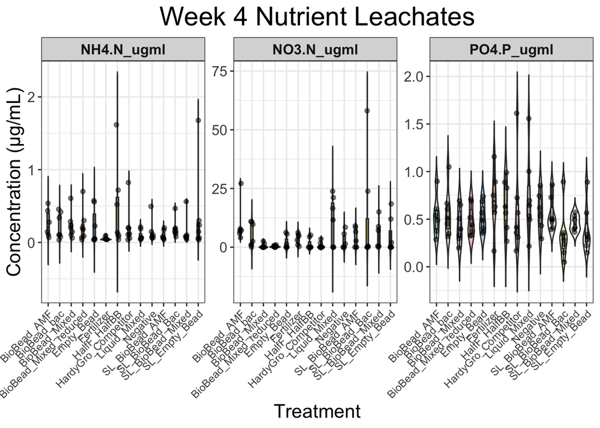

### 2.2.2 Correlation scatterplots

Correlation scatterplots were generated to assess the correlations between nitrate and phosphate and ammonium.

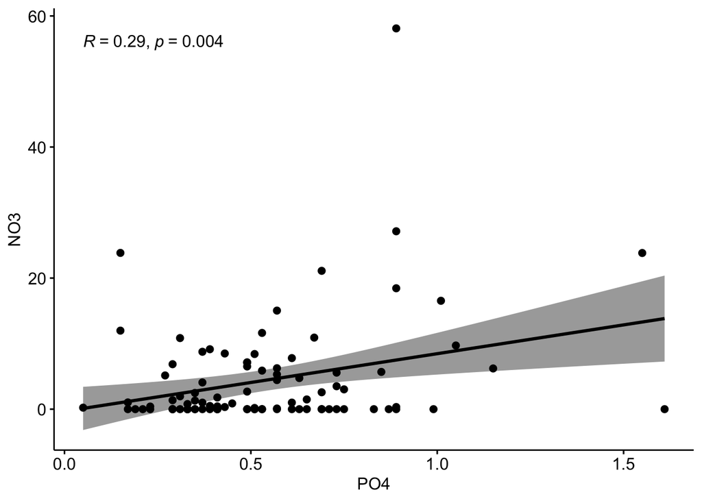

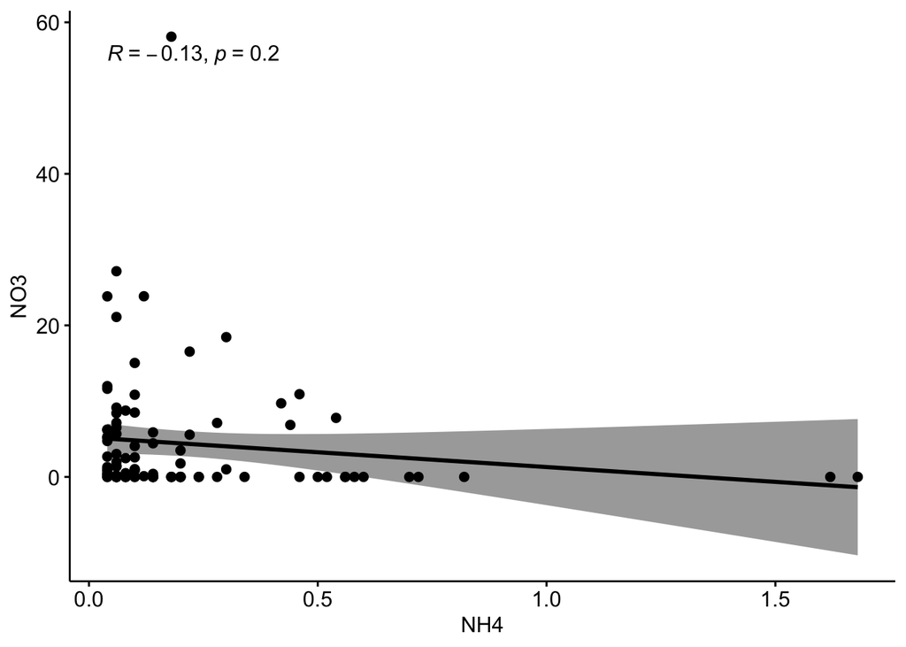

### 2.2.3 One Way ANOVA

```r
summary(anova_NH4_wk4)
```

```
##                    Df Sum Sq Mean Sq F value Pr(>F)
## Treatment_Category 13  0.986 0.07583   0.968   0.49
## Residuals          80  6.269 0.07836
```

```r
summary(anova_NO3_wk4)
```

```
##                    Df Sum Sq Mean Sq F value Pr(>F)
## Treatment_Category 13   1271   97.74   1.572  0.111
## Residuals          80   4973   62.16
```

```r
summary(anova_PO4_wk4)
```

```
##                    Df Sum Sq Mean Sq F value Pr(>F)
## Treatment_Category 13  1.133 0.08716   1.192  0.301
## Residuals          80  5.850 0.07312
```

There were no significant differences among treatment groups for ammonium, nitrate, or phosphate concentrations in leachate.

### 2.2.4 Tukey Test

```r
tukey_NH4_wk4 <- TukeyHSD(x=anova_NH4_wk4, ordered=TRUE, conf.level=0.95)
#print(tukey_NH4_wk4)

tukey_NO3_wk4 <- TukeyHSD(x=anova_NO3_wk4, ordered=TRUE, conf.level=0.95)
#print(tukey_NO3_wk4)

tukey_PO4_wk4 <- TukeyHSD(x=anova_PO4_wk4, ordered=TRUE, conf.level=0.95)
#print(tukey_PO4_wk4)
```

There were no significant differences among treatment groups for ammonium, nitrate, or phosphate concentrations in leachate.

### 2.2.5 Shapiro Wilk test for normality

```
##
##  Shapiro-Wilk normality test
##
## data:  anova_NH4_wk4$residuals
## W = 0.77091, p-value = 8.526e-11
```

```
##
##  Shapiro-Wilk normality test
##
## data:  anova_NO3_wk4$residuals
## W = 0.77616, p-value = 1.19e-10
```

```
##
##  Shapiro-Wilk normality test
##
## data:  anova_PO4_wk4$residuals
## W = 0.92579, p-value = 4.938e-05
```

### 2.2.6 Residuals distribution

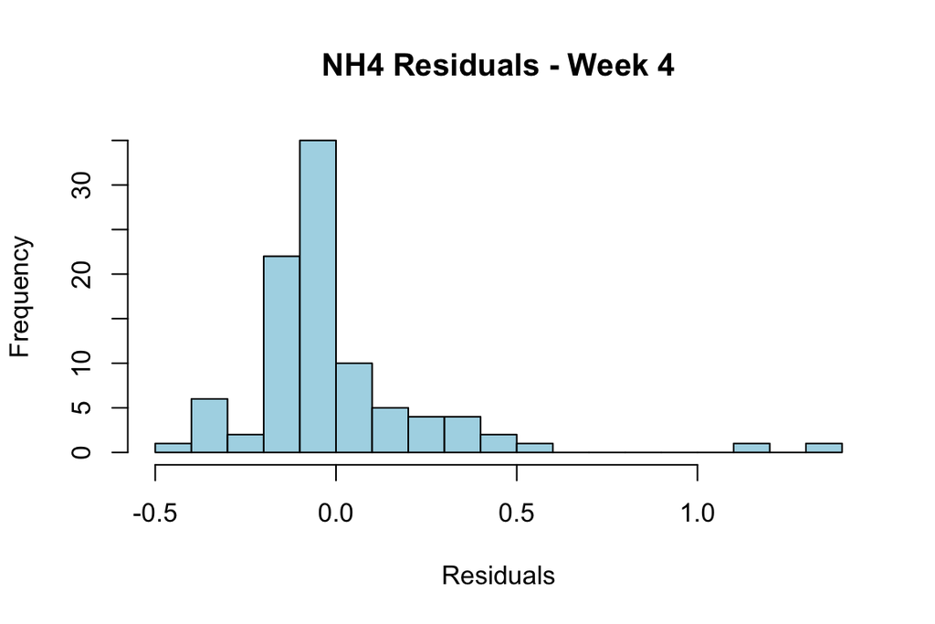

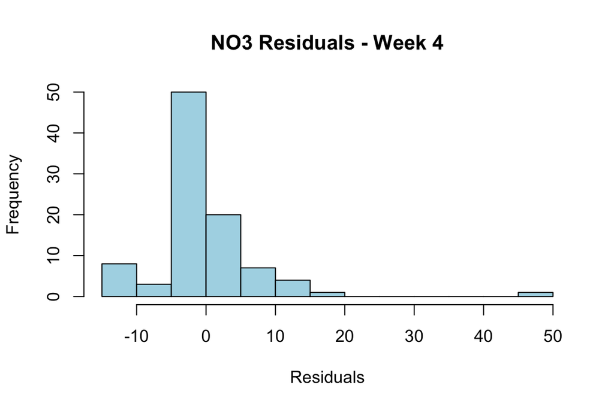

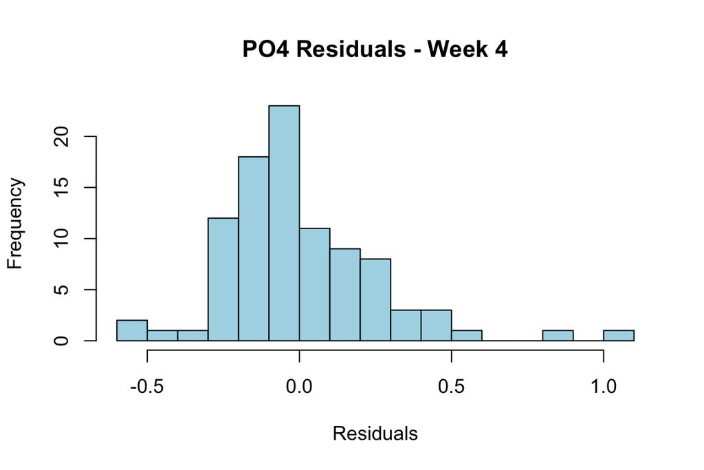

### 2.2.7 Quantile-Quantile plots

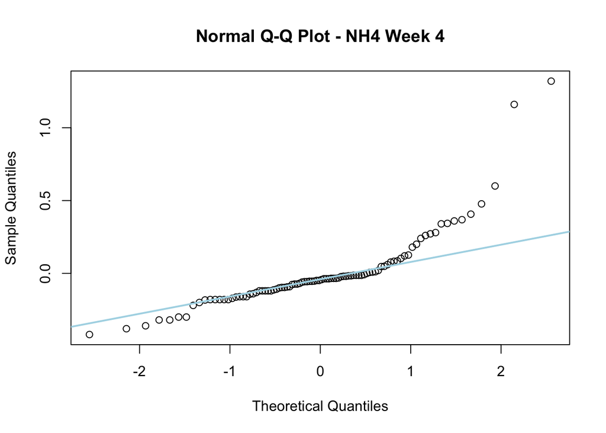

```r
qqnorm(anova_NH4_wk4$residuals, main = "Normal Q-Q Plot - NH4 Week 4")
qqline(anova_NH4_wk4$residuals, col = "lightblue", lwd = 2)
```

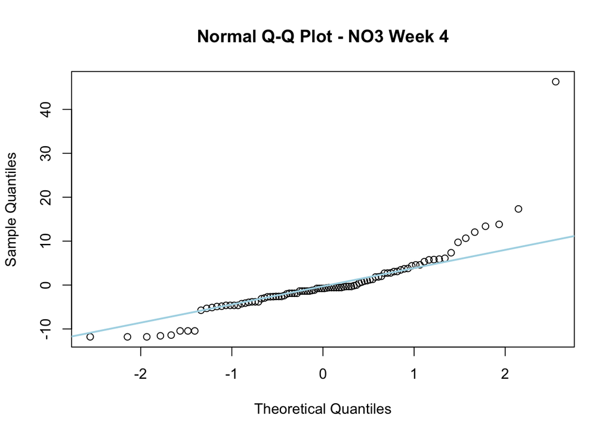

```r
qqnorm(anova_NO3_wk4$residuals, main = "Normal Q-Q Plot - NO3 Week 4")
qqline(anova_NO3_wk4$residuals, col = "lightblue", lwd = 2)
```

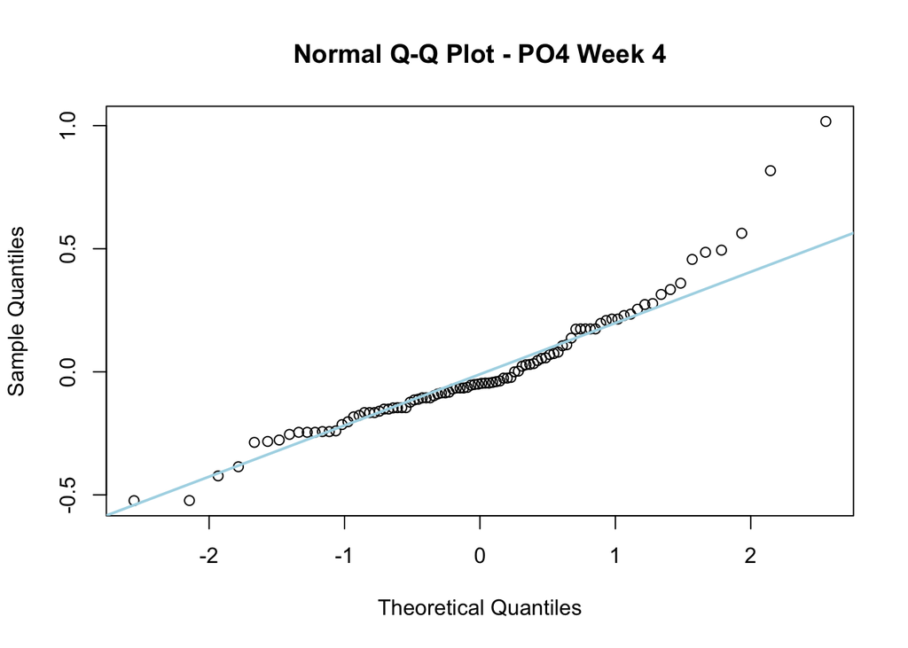

```r
qqnorm(anova_PO4_wk4$residuals, main = "Normal Q-Q Plot - PO4 Week 4")
qqline(anova_PO4_wk4$residuals, col = "lightblue", lwd = 2)
```

## 2.3 Week 6 Analysis

### 2.3.1 Faceted violin plot

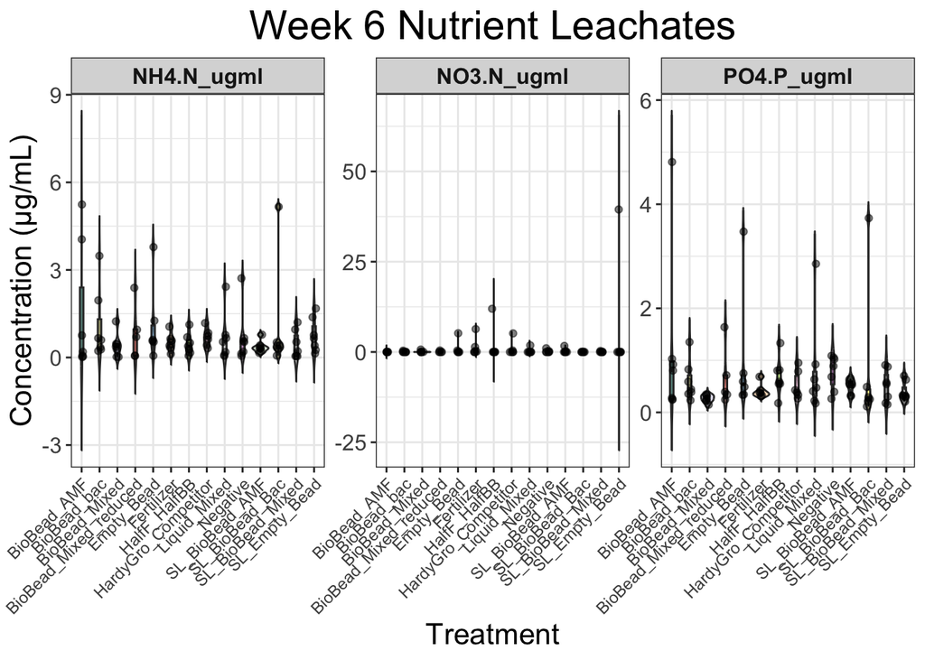

### 2.3.2 Correlation scatterplots

Correlation scatterplots were generated to assess the correlations between nitrate and phosphate and ammonium.

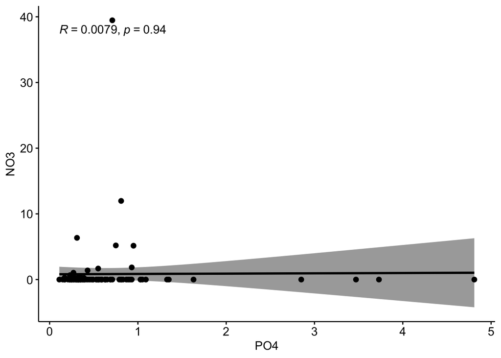

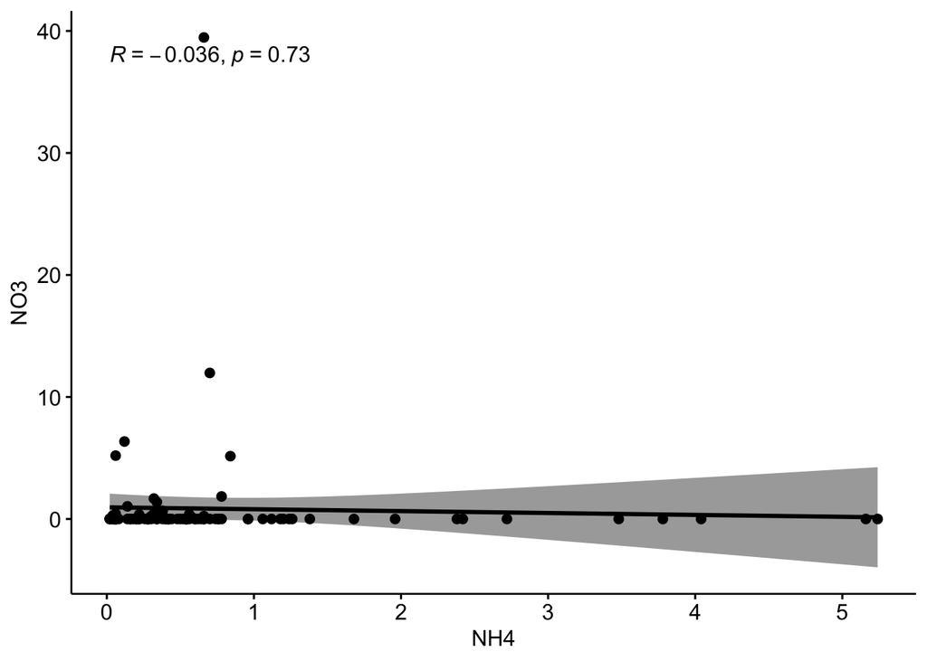

### 2.3.3 One Way ANOVA

```r
summary(anova_NH4_wk6)
```

```
##                    Df Sum Sq Mean Sq F value Pr(>F)
## Treatment_Category 13   9.80   0.754   0.685  0.772
## Residuals          78  85.87   1.101
```

```r
summary(anova_NO3_wk6)
```

```
##                    Df Sum Sq Mean Sq F value Pr(>F)
## Treatment_Category 13  200.1   15.39    0.78  0.679
## Residuals          78 1540.3   19.75
```

```r
summary(anova_PO4_wk6)
```

```
##                    Df Sum Sq Mean Sq F value Pr(>F)
## Treatment_Category 13   5.52  0.4245   0.758  0.701
## Residuals          78  43.70  0.5603
```

There were no significant differences among treatment groups for ammonium, nitrate, or phosphate concentrations in leachate.

### 2.3.4 Tukey Test

There were no significant differences among treatment groups for ammonium, nitrate, or phosphate concentrations in leachate.

### 2.3.5 Shapiro Wilk test for normality

```
##
##  Shapiro-Wilk normality test
##
## data:  anova_NH4_wk6$residuals
## W = 0.80185, p-value = 8.809e-10
```

```
##
##  Shapiro-Wilk normality test
##
## data:  anova_NO3_wk6$residuals
## W = 0.3975, p-value < 2.2e-16
```

```
##
##  Shapiro-Wilk normality test
##
## data:  anova_PO4_wk6$residuals
## W = 0.68731, p-value = 1.064e-12
```

### 2.3.6 Residuals distribution

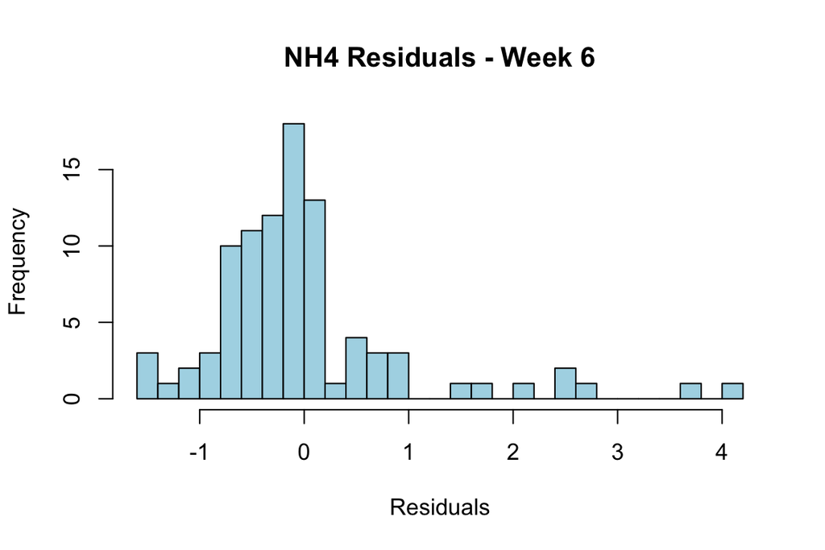

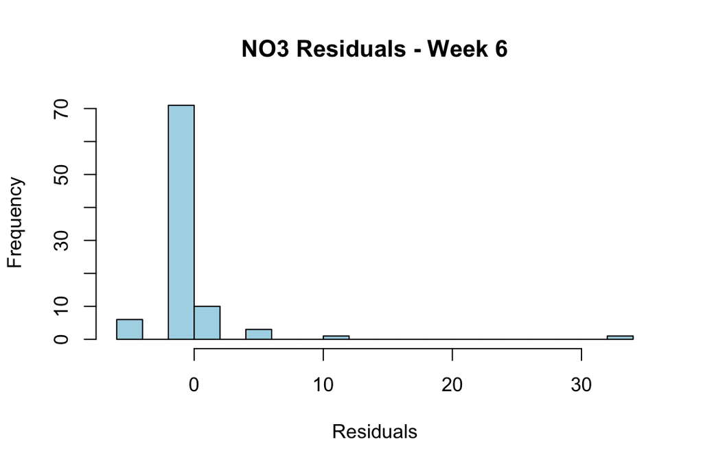

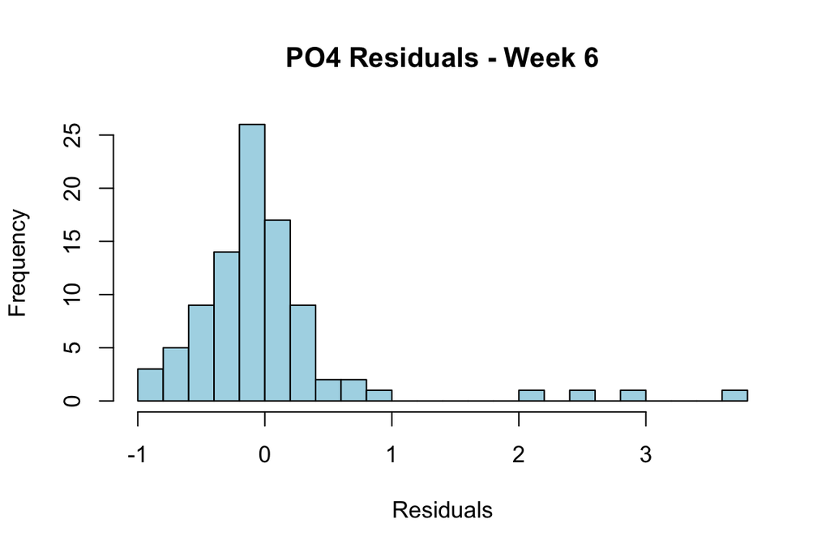

### 2.3.7 Quantile-Quantile plots

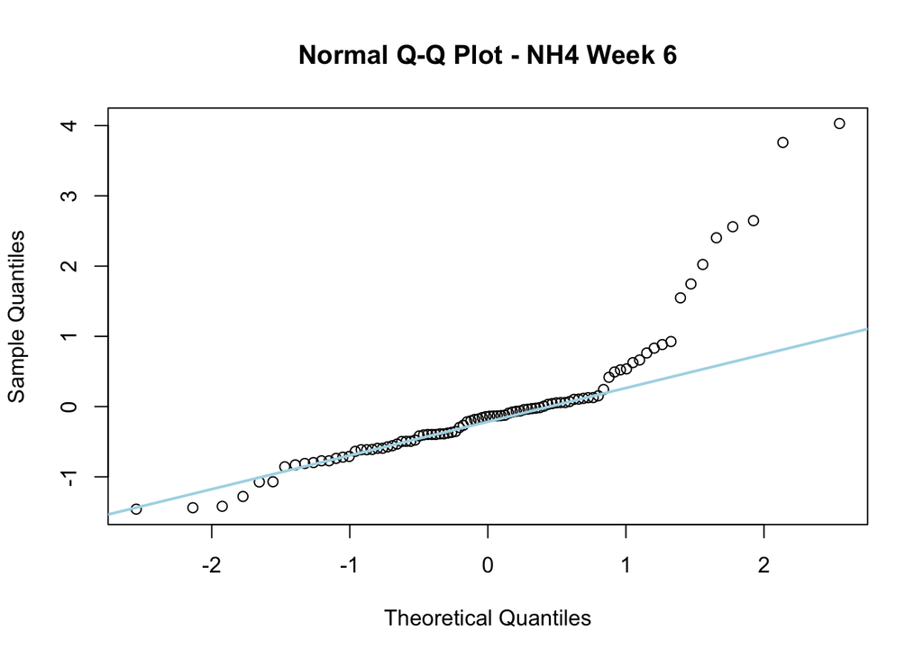

```r
qqnorm(anova_NH4_wk6$residuals, main = "Normal Q-Q Plot - NH4 Week 6")
qqline(anova_NH4_wk6$residuals, col = "lightblue", lwd = 2)
```

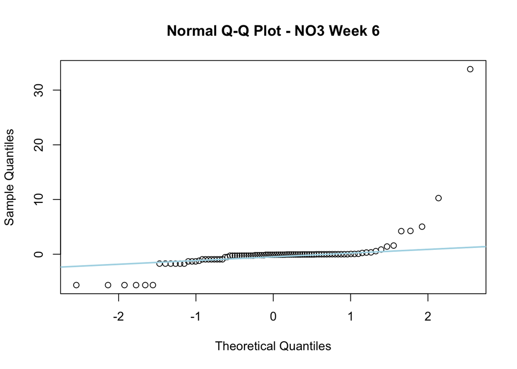

```r
qqnorm(anova_NO3_wk6$residuals, main = "Normal Q-Q Plot - NO3 Week 6")
qqline(anova_NO3_wk6$residuals, col = "lightblue", lwd = 2)
```

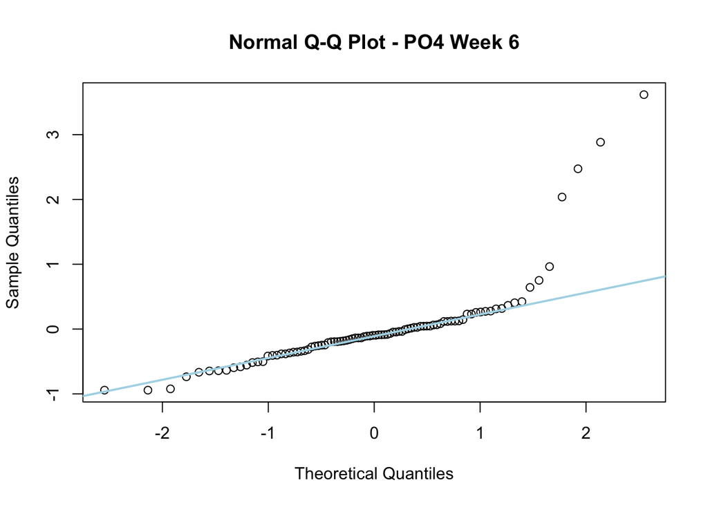

```r
qqnorm(anova_PO4_wk6$residuals, main = "Normal Q-Q Plot - PO4 Week 6")
qqline(anova_PO4_wk6$residuals, col = "lightblue", lwd = 2)
```

## 2.4 Week 8 Analysis

### 2.4.1 Faceted violin plot

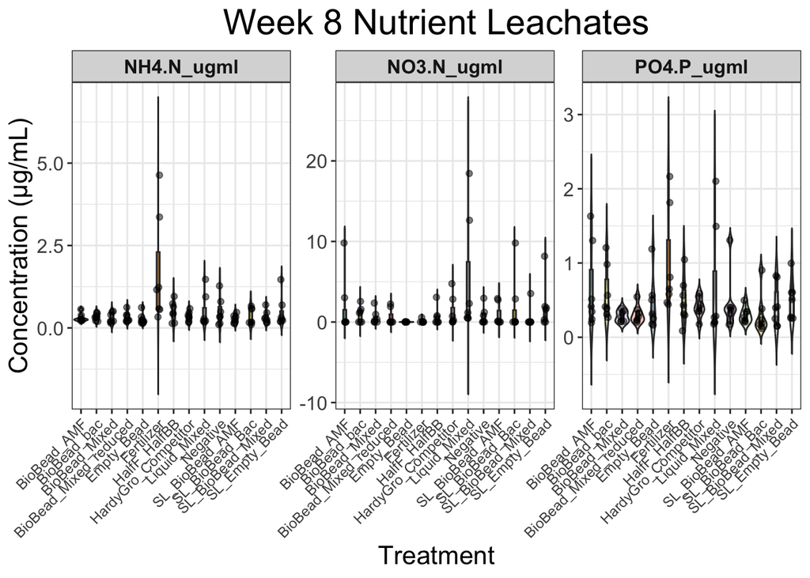

### 2.4.2 Correlation scatterplots

Correlation scatterplots were generated to assess the correlations between nitrate and phosphate and ammonium.

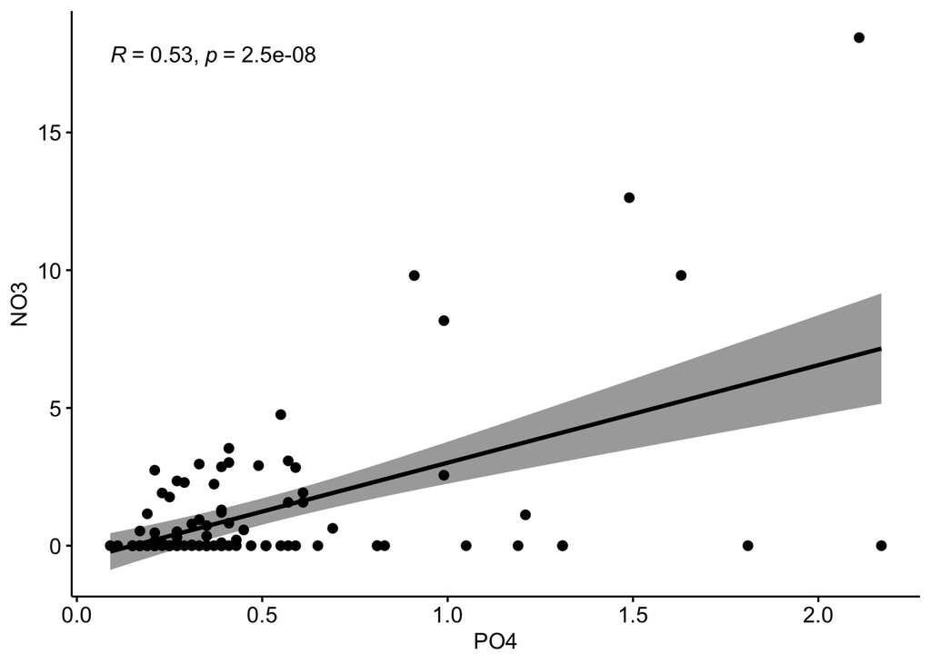

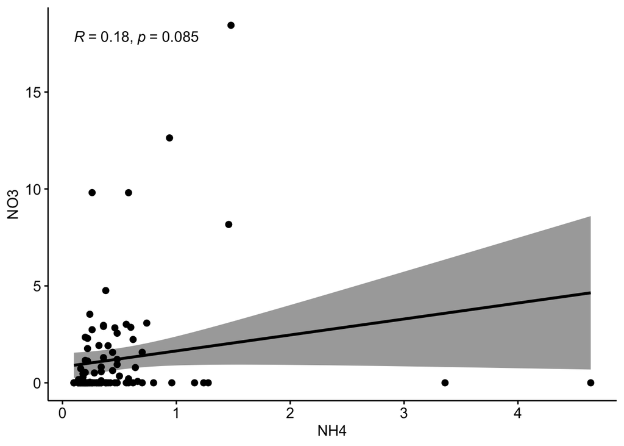

### 2.4.3 One Way ANOVA

```r
summary(anova_NH4_wk8)
```

```
##                    Df Sum Sq Mean Sq F value   Pr(>F)
## Treatment_Category 13  12.11  0.9313   3.524 0.000213 ***
## Residuals          84  22.20  0.2643
## ---
## Signif. codes:  0 '***' 0.001 '**' 0.01 '*' 0.05 '.' 0.1 ' ' 1
```

```r
summary(anova_NO3_wk8)
```

```
##                    Df Sum Sq Mean Sq F value Pr(>F)
## Treatment_Category 13  151.6  11.662   1.612  0.098 .
## Residuals          84  607.8   7.236
## ---
## Signif. codes:  0 '***' 0.001 '**' 0.01 '*' 0.05 '.' 0.1 ' ' 1
```

```r
summary(anova_PO4_wk8)
```

```
##                    Df Sum Sq Mean Sq F value Pr(>F)
## Treatment_Category 13  3.401  0.2616   1.642 0.0899 .
## Residuals          84 13.389  0.1594
## ---
## Signif. codes:  0 '***' 0.001 '**' 0.01 '*' 0.05 '.' 0.1 ' ' 1
```

There were no significant differences among treatment groups for nitrate or phosphate concentrations in leachate. However ammonium shows highly significant differences among treatments.